# Scaling E-commerce operations in emerging markets: Brazilian SMEs

## Introduction

### Purpose

The purpose of this prooject is to show how mid-sized companies can leverage sales data analytics to overcame growth plateaus and scale.

### Context

For this project, we will use a dataset containing sales data for a mid-sized Brazilian e-commerce company, with information of 100k orders from 2016 to 2018. This dataset was prepared and shared by Olist on [Kaggle](https://www.kaggle.com/datasets/olistbr/brazilian-ecommerce).

### Problems we want to solve

For a company, sales are the most important and available data. But analyze this huge datasets could be hard and sometimes data are note cleaned enough.

[figure not shown]

In this case study we want to address problems that many business owners and how to analize sales track records effectively is one of the most frequent.

Also, how can we use those data to segment and reinforce cross-selling?

### About me and why I'm writing this

I am a Business Transformation and Scalability Engineer.

I help companies to overcome growth thresholds and crisis, like generational transition, market consolidation, and economic downturns, both as a consultant and as a temporary executive. I work directly with business owners, executives and top-management.

I have a background as a Management Engineer and an experience in a 2nd to 3rd generation family business, 250 people, 60-80M€ revenue, called [Urania Group](https://urania.group). In Urania, I operated in many field. Accidentally, my first task in Urania Group was to operate as a Sales Manager in the Brazilian market 2014-2016. I have been the CEO of the controlled company Serrall from 2018 to 2024, when I left the governance of the company.

Since then, I focused on high-level, strategic consultancy for mid-sized companies. In 2025 I started a new company where I am developing software solutions for mid-sized companies focused on intelligence, growth for owners, executives and top-management.

You can find more about me and my work on my [personale website](https://matteocervelli.com/en/about/) and on [LinkedIn](https://www.linkedin.com/in/matteocervelli/).

This project is part of the [Google Data Analytics Professional Certificate](https://www.coursera.org/professional-certificates/google-data-analytics) by Google and Coursera. This is my first publicly available project, and I'm sharing it as a case study, portfolio project.

[figure not shown]

## Ask

This case study try to address general questions related to business intelligence, like:

- **Time Between Orders**: Which is the mean time occurring between the first and the second order for a returning customer? How does this compare with the following orders? Can we identify a pattern for TBO to predict churn?
- What is the mean **churn rate** in market? How can we position companies in churn-rate vs reviews?
- How can we **segment** customers?
- How do different products relate and support **cross-selling**?\
- **Value Ladder**: Can we find front-end and back-end products just from ordered products?
- **Sales prediction**: is it possible from past sales?

Particularly for the use case:

- What is the seasonality and how can we find different clusters of products based on seasonality?
- Which are the most sold products categories?
- How can we map product categories in prices per unit vs. average sales?
- Is there a correlation between reviews and Time Between Orders?

[figure not shown]

Picture by [Amy Hirschi](https://unsplash.com/it/@amyhirschi?utm_content=creditCopyText&utm_medium=referral&utm_source=unsplash) on [Unsplash](https://unsplash.com/it/foto/donna-in-t-shirt-verde-acqua-che-si-siede-accanto-alla-donna-in-giacca-del-vestito-JaoVGh5aJ3E?utm_content=creditCopyText&utm_medium=referral&utm_source=unsplash)

## Prepare

I download the dataset from Kaggle.

The dataset has 9 tables:

- Core orders dataset
- Order items
- Order payments
- Order reviews
- Customers
- Brazilian zip codes and coordinates
- Products
- Sellers
- Product category name translations from Brazilian to English

[figure not shown]

```r
# Needed packages loaded
library(tidyverse)
library(readr)
library(lubridate)
library(skimr)
library(dplyr)
library(janitor)
library(ggplot2)
library(scales)
library(gridExtra)
library(treemapify)
library(maps)
library(ggmap)
library(viridis)
library(arules)
library(arulesViz)
library(forecast)
```

```r
# Tables imported
customers <- read_csv("./dataset/olist_customers_dataset.csv")
geolocation <- read_csv("./dataset/olist_geolocation_dataset.csv")
order_items <- read_csv("./dataset/olist_order_items_dataset.csv")
order_payments <- read_csv("./dataset/olist_order_payments_dataset.csv")
order_reviews <- read_csv("./dataset/olist_order_reviews_dataset.csv")
orders <- read_csv("./dataset/olist_orders_dataset.csv")
products <- read_csv("./dataset/olist_products_dataset.csv")
sellers <- read_csv("./dataset/olist_sellers_dataset.csv")
category_names_translation <- read_csv("./dataset/product_category_name_translation.csv")
```

```r
cat("-----Snapshot of ORDERS table\n")
glimpse(orders)

cat("\n-----Snapshot of CUSTOMERS table\n")
glimpse(customers)

cat("\n-----Snapshot of ORDER_ITEMS table\n")
glimpse(order_items)

cat("\n-----Snapshot of ORDER_PAYMENTS table\n")
glimpse(order_payments)

cat("\n-----Snapshot of ORDER_REVIEWS table\n")
glimpse(order_reviews)

cat("\n-----Snapshot of CUSTOMERS table\n")
glimpse(customers)

cat("\n-----Snapshot of SELLERS table\n")
glimpse(sellers)

cat("\n-----Snapshot of GEOLOCATION table\n")
glimpse(geolocation)

cat("\n-----Snapshot of PRODUCTS table\n")
glimpse(products)

cat("\n-----Snapshot of CATEGORY_NAME_TRANSLATIONS table\n")
glimpse(category_names_translation)
```

```
-----Snapshot of ORDERS table
Rows: 99,441
Columns: 8
$ order_id                      <chr> "e481f51cbdc54678b7cc49136f2d6af7", "53c…
$ customer_id                   <chr> "9ef432eb6251297304e76186b10a928d", "b08…
$ order_status                  <chr> "delivered", "delivered", "delivered", "…
$ order_purchase_timestamp      <dttm> 2017-10-02 10:56:33, 2018-07-24 20:41:3…
$ order_approved_at             <dttm> 2017-10-02 11:07:15, 2018-07-26 03:24:2…
$ order_delivered_carrier_date  <dttm> 2017-10-04 19:55:00, 2018-07-26 14:31:0…
$ order_delivered_customer_date <dttm> 2017-10-10 21:25:13, 2018-08-07 15:27:4…
$ order_estimated_delivery_date <dttm> 2017-10-18, 2018-08-13, 2018-09-04, 201…

-----Snapshot of CUSTOMERS table
Rows: 99,441
Columns: 5
$ customer_id              <chr> "06b8999e2fba1a1fbc88172c00ba8bc7", "18955e83…
$ customer_unique_id       <chr> "861eff4711a542e4b93843c6dd7febb0", "290c77bc…
$ customer_zip_code_prefix <chr> "14409", "09790", "01151", "08775", "13056", …
$ customer_city            <chr> "franca", "sao bernardo do campo", "sao paulo…
$ customer_state           <chr> "SP", "SP", "SP", "SP", "SP", "SC", "SP", "MG…

-----Snapshot of ORDER_ITEMS table
Rows: 112,650
Columns: 7
$ order_id            <chr> "00010242fe8c5a6d1ba2dd792cb16214", "00018f77f2f03…
$ order_item_id       <dbl> 1, 1, 1, 1, 1, 1, 1, 1, 1, 1, 1, 1, 1, 1, 2, 1, 1,…
$ product_id          <chr> "4244733e06e7ecb4970a6e2683c13e61", "e5f2d52b80218…
$ seller_id           <chr> "48436dade18ac8b2bce089ec2a041202", "dd7ddc04e1b6c…
$ shipping_limit_date <dttm> 2017-09-19 09:45:35, 2017-05-03 11:05:13, 2018-01…
$ price               <dbl> 58.90, 239.90, 199.00, 12.99, 199.90, 21.90, 19.90…
$ freight_value       <dbl> 13.29, 19.93, 17.87, 12.79, 18.14, 12.69, 11.85, 7…

-----Snapshot of ORDER_PAYMENTS table
Rows: 103,886
Columns: 5
$ order_id             <chr> "b81ef226f3fe1789b1e8b2acac839d17", "a9810da82917…
$ payment_sequential   <dbl> 1, 1, 1, 1, 1, 1, 1, 1, 1, 1, 1, 1, 1, 1, 1, 1, 1…
$ payment_type         <chr> "credit_card", "credit_card", "credit_card", "cre…
$ payment_installments <dbl> 8, 1, 1, 8, 2, 2, 1, 3, 6, 1, 8, 1, 1, 5, 4, 10, …
$ payment_value        <dbl> 99.33, 24.39, 65.71, 107.78, 128.45, 96.12, 81.16…
```

[output cut: 41 more lines]

```
$ product_id                 <chr> "1e9e8ef04dbcff4541ed26657ea517e5", "3aa071…
$ product_category_name      <chr> "perfumaria", "artes", "esporte_lazer", "be…
$ product_name_lenght        <dbl> 40, 44, 46, 27, 37, 60, 56, 56, 57, 36, 54,…
$ product_description_lenght <dbl> 287, 276, 250, 261, 402, 745, 1272, 184, 16…
$ product_photos_qty         <dbl> 1, 1, 1, 1, 4, 1, 4, 2, 1, 1, 1, 4, 3, 2, 4…
$ product_weight_g           <dbl> 225, 1000, 154, 371, 625, 200, 18350, 900, …
$ product_length_cm          <dbl> 16, 30, 18, 26, 20, 38, 70, 40, 27, 17, 16,…
$ product_height_cm          <dbl> 10, 18, 9, 4, 17, 5, 24, 8, 13, 10, 10, 19,…
$ product_width_cm           <dbl> 14, 20, 15, 26, 13, 11, 44, 40, 17, 12, 16,…

-----Snapshot of CATEGORY_NAME_TRANSLATIONS table
Rows: 71
Columns: 2
$ product_category_name         <chr> "beleza_saude", "informatica_acessorios"…
$ product_category_name_english <chr> "health_beauty", "computers_accessories"…
```

The dataset is well organized, columns names are great and also we are provided with a useful translation from Brazilian to English.

## Process

The main table is the ORDERS table, but the most important data is in the ORDER_ITEMS table. We will consider this as the main table from where to choose the columns and joins everything. So we will create a massive table from here.

At the end we would do analysis on customers and sellers for quantity, recurrency, ABC, and then on products, as a first touch.

We must also rename, while doing the join, the geolocation columns for sellers and customers, to have them duplicated.

```r
tryCatch({
  merged_table <- order_items %>%
    left_join(orders, by = "order_id") %>%
    left_join(order_reviews, by = "order_id", relationship =
  "many-to-many") %>%
    left_join(order_payments, by = "order_id", relationship =
  "many-to-many") %>%
    left_join(customers, by = "customer_id") %>%
    left_join(geolocation, by = c("customer_zip_code_prefix" = "geolocation_zip_code_prefix")) %>%
    rename(customer_lat = geolocation_lat, customer_lng = geolocation_lng) %>%
    left_join(sellers, by = "seller_id") %>%
    left_join(geolocation, by = c("seller_zip_code_prefix" = "geolocation_zip_code_prefix")) %>%
    rename(seller_lat = geolocation_lat, seller_lng = geolocation_lng) %>%
    left_join(products, by = "product_id") %>%
    left_join(category_names_translation, by = "product_category_name") %>%
    select(-product_category_name) %>%
    rename(product_category_name = product_category_name_translation)
},
error = function(e) {
  cat("Error: ", e$message, "\n")
  return(NULL)
}
)
```

```
Error:  This join would result in more rows than dplyr can handle.
```

There's and error. The suspect is the geolocation table.

Let's check how many rows are after the join with geolocation.

```r
merged_table_before <- order_items %>%
    left_join(orders, by = "order_id") %>%
    left_join(order_reviews, by = "order_id", relationship =
  "many-to-many") %>%
    left_join(order_payments, by = "order_id", relationship =
  "many-to-many") %>%
    left_join(customers, by = "customer_id")


cat("Number of rows before join with customer geolocation:", nrow(merged_table_before), "rows\n")

 merged_table_after <-merged_table_before %>%
    left_join(geolocation, by = c("customer_zip_code_prefix" = "geolocation_zip_code_prefix"), relationship = "many-to-many")

cat("Number of rows after join with customer geolocation:", nrow(merged_table_after), "rows\n")

cat("It explodes", (nrow(merged_table_after) / nrow(merged_table_before)), "times\n")
```

```
Number of rows before join with customer geolocation: 118310 rows
Number of rows after join with customer geolocation: 18064261 rows
It explodes 152.6858 times
```

There's and explosion of rows, over 152 times. Let's check why, we suspect that each zip code is mapping many points on the map.

```r
geolocation_duplicates <- geolocation %>%
    count(geolocation_zip_code_prefix) %>%
    arrange(desc(n))

  head(geolocation_duplicates, 20)
  summary(geolocation_duplicates$n)
```

A tibble: 20 × 2

| geolocation_zip_code_prefix <chr> | n <int> |
| --- | --- |
| 24220 | 1146 |
| 24230 | 1102 |
| 38400 | 965 |
| 35500 | 907 |
| 11680 | 879 |
| 22631 | 832 |
| 30140 | 810 |
| 11740 | 788 |
| 38408 | 773 |
| 28970 | 743 |
| 36400 | 733 |
| 39400 | 724 |
| 37701 | 714 |
| 35162 | 713 |
| 35900 | 709 |
| 37200 | 696 |
| 88330 | 694 |
| 22790 | 687 |
| 35700 | 678 |
| 36570 | 667 |

```
   Min. 1st Qu.  Median    Mean 3rd Qu.    Max.
    1.0    10.0    29.0    52.6    66.5  1146.0
```

Prefix 24220 has 1146 point on the map! And it's only the first result.

```r
head(filter(geolocation, geolocation_zip_code_prefix == "24220"))
```

A tibble: 6 × 5

| geolocation_zip_code_prefix <chr> | geolocation_lat <dbl> | geolocation_lng <dbl> | geolocation_city <chr> | geolocation_state <chr> |
| --- | --- | --- | --- | --- |
| 24220 | -22.90582 | -43.10699 | niteroi | RJ |
| 24220 | -22.90231 | -43.11254 | niteroi | RJ |
| 24220 | -22.90457 | -43.11049 | niteroi | RJ |
| 24220 | -22.90257 | -43.10919 | niteroi | RJ |
| 24220 | -22.90750 | -43.10617 | niteroi | RJ |
| 24220 | -22.90432 | -43.11300 | niteroi | RJ |

Well, Niteroi is amazing. But we have to resolve this problem

[figure not shown]

To have a good enough result, we can use the first point for the geolocation. To have an above average result we can set each zip_code to the average value. To have an EXCELLENT result we can set each zip_code to the median value.

Nothing is easier with R.

```r
geolocation_median <- geolocation %>%
  group_by(geolocation_zip_code_prefix) %>%
  summarise(
    geolocation_lat = median(geolocation_lat, na.rm = TRUE),
    geolocation_lng = median(geolocation_lng, na.rm = TRUE),
    geolocation_city = first(geolocation_city),
    geolocation_state = first(geolocation_state),
    .groups = 'drop'
  )

cat("Number of rows in the original geolocation table:", nrow(geolocation), "\n")
cat("Number of rows in the new geolocation_median table:", nrow(geolocation_median), "\n")

cat("We have a reduction in the number of rows of", (nrow(geolocation) / nrow(geolocation_median)), "times\n")

cat("\nOriginal geolocation table for Niteroi\n")
head(filter(geolocation, geolocation_zip_code_prefix == "24220"))

cat("\nNew geolocation_median table for Niteroi\n")
head(filter(geolocation_median, geolocation_zip_code_prefix == "24220"))
```

```
Number of rows in the original geolocation table: 1000163
Number of rows in the new geolocation_median table: 19015
We have a reduction in the number of rows of 52.59863 times

Original geolocation table for Niteroi
```

A tibble: 6 × 5

| geolocation_zip_code_prefix <chr> | geolocation_lat <dbl> | geolocation_lng <dbl> | geolocation_city <chr> | geolocation_state <chr> |
| --- | --- | --- | --- | --- |
| 24220 | -22.90582 | -43.10699 | niteroi | RJ |
| 24220 | -22.90231 | -43.11254 | niteroi | RJ |
| 24220 | -22.90457 | -43.11049 | niteroi | RJ |
| 24220 | -22.90257 | -43.10919 | niteroi | RJ |
| 24220 | -22.90750 | -43.10617 | niteroi | RJ |
| 24220 | -22.90432 | -43.11300 | niteroi | RJ |

```
New geolocation_median table for Niteroi
```

A tibble: 1 × 5

| geolocation_zip_code_prefix <chr> | geolocation_lat <dbl> | geolocation_lng <dbl> | geolocation_city <chr> | geolocation_state <chr> |
| --- | --- | --- | --- | --- |
| 24220 | -22.90317 | -43.10713 | niteroi | RJ |

That's great. Now let's do the join with the geolocation_median table.

```r
merged_table_all <- order_items %>%
    left_join(orders, by = "order_id") %>%
    rename(order_item_count = order_item_id) %>%
    mutate(order_item_id = paste0(order_id, "-", order_item_count)) %>%
    left_join(order_reviews, by = "order_id", relationship =
  "many-to-many") %>%
    left_join(order_payments, by = "order_id", relationship =
  "many-to-many") %>%
    left_join(customers, by = "customer_id") %>%
    left_join(geolocation_median, by = c("customer_zip_code_prefix" = "geolocation_zip_code_prefix")) %>%
    rename(customer_lat = geolocation_lat, customer_lng = geolocation_lng) %>%
    left_join(sellers, by = "seller_id") %>%
    left_join(geolocation_median, by = c("seller_zip_code_prefix" = "geolocation_zip_code_prefix")) %>%
    rename(seller_lat = geolocation_lat, seller_lng = geolocation_lng) %>%
    left_join(products, by = "product_id") %>%
    left_join(category_names_translation, by = "product_category_name") %>%
    select(-product_category_name) %>%
    rename(product_category_name = product_category_name_english)

# Remove duplicate rows
merged_table <- merged_table_all %>%
    distinct(order_item_id, .keep_all = TRUE)
```

```r
# Visualize the merged table

head(merged_table)

cat("Number of rows in the merged_table:", nrow(merged_table), "\n")
cat("Number of rows in the original order_items table:", nrow(merged_table), "\n")
cat("We have ", nrow(merged_table) - nrow(order_items) - 1, "rows more than the original number of rows, an increase of", (percent(nrow(merged_table) / nrow(order_items) -1)), "\n\n")

glimpse(merged_table)
```

A tibble: 6 × 48

| order_id <chr> | order_item_count <dbl> | product_id <chr> | seller_id <chr> | shipping_limit_date <dttm> | price <dbl> | freight_value <dbl> | customer_id <chr> | order_status <chr> | order_purchase_timestamp <dttm> | ⋯ | geolocation_city.y <chr> | geolocation_state.y <chr> | product_name_lenght <dbl> | product_description_lenght <dbl> | product_photos_qty <dbl> | product_weight_g <dbl> | product_length_cm <dbl> | product_height_cm <dbl> | product_width_cm <dbl> | product_category_name <chr> |
| --- | --- | --- | --- | --- | --- | --- | --- | --- | --- | --- | --- | --- | --- | --- | --- | --- | --- | --- | --- | --- |
| 00010242fe8c5a6d1ba2dd792cb16214 | 1 | 4244733e06e7ecb4970a6e2683c13e61 | 48436dade18ac8b2bce089ec2a041202 | 2017-09-19 09:45:35 | 58.90 | 13.29 | 3ce436f183e68e07877b285a838db11a | delivered | 2017-09-13 08:59:02 | ⋯ | volta redonda | RJ | 58 | 598 | 4 | 650 | 28 | 9 | 14 | cool_stuff |
| 00018f77f2f0320c557190d7a144bdd3 | 1 | e5f2d52b802189ee658865ca93d83a8f | dd7ddc04e1b6c2c614352b383efe2d36 | 2017-05-03 11:05:13 | 239.90 | 19.93 | f6dd3ec061db4e3987629fe6b26e5cce | delivered | 2017-04-26 10:53:06 | ⋯ | sao paulo | SP | 56 | 239 | 2 | 30000 | 50 | 30 | 40 | pet_shop |
| 000229ec398224ef6ca0657da4fc703e | 1 | c777355d18b72b67abbeef9df44fd0fd | 5b51032eddd242adc84c38acab88f23d | 2018-01-18 14:48:30 | 199.00 | 17.87 | 6489ae5e4333f3693df5ad4372dab6d3 | delivered | 2018-01-14 14:33:31 | ⋯ | borda da mata | MG | 59 | 695 | 2 | 3050 | 33 | 13 | 33 | furniture_decor |
| 00024acbcdf0a6daa1e931b038114c75 | 1 | 7634da152a4610f1595efa32f14722fc | 9d7a1d34a5052409006425275ba1c2b4 | 2018-08-15 10:10:18 | 12.99 | 12.79 | d4eb9395c8c0431ee92fce09860c5a06 | delivered | 2018-08-08 10:00:35 | ⋯ | franca | SP | 42 | 480 | 1 | 200 | 16 | 10 | 15 | perfumery |
| 00042b26cf59d7ce69dfabb4e55b4fd9 | 1 | ac6c3623068f30de03045865e4e10089 | df560393f3a51e74553ab94004ba5c87 | 2017-02-13 13:57:51 | 199.90 | 18.14 | 58dbd0b2d70206bf40e62cd34e84d795 | delivered | 2017-02-04 13:57:51 | ⋯ | loanda | PR | 59 | 409 | 1 | 3750 | 35 | 40 | 30 | garden_tools |
| 00048cc3ae777c65dbb7d2a0634bc1ea | 1 | ef92defde845ab8450f9d70c526ef70f | 6426d21aca402a131fc0a5d0960a3c90 | 2017-05-23 03:55:27 | 21.90 | 12.69 | 816cbea969fe5b689b39cfc97a506742 | delivered | 2017-05-15 21:42:34 | ⋯ | ribeirao preto | SP | 36 | 558 | 1 | 450 | 24 | 8 | 15 | housewares |

```
Number of rows in the merged_table: 112650
Number of rows in the original order_items table: 112650
We have  -1 rows more than the original number of rows, an increase of 0%

Rows: 112,650
Columns: 48
$ order_id                      <chr> "00010242fe8c5a6d1ba2dd792cb16214", "000…
$ order_item_count              <dbl> 1, 1, 1, 1, 1, 1, 1, 1, 1, 1, 1, 1, 1, 1…
$ product_id                    <chr> "4244733e06e7ecb4970a6e2683c13e61", "e5f…
$ seller_id                     <chr> "48436dade18ac8b2bce089ec2a041202", "dd7…
$ shipping_limit_date           <dttm> 2017-09-19 09:45:35, 2017-05-03 11:05:1…
$ price                         <dbl> 58.90, 239.90, 199.00, 12.99, 199.90, 21…
$ freight_value                 <dbl> 13.29, 19.93, 17.87, 12.79, 18.14, 12.69…
$ customer_id                   <chr> "3ce436f183e68e07877b285a838db11a", "f6d…
$ order_status                  <chr> "delivered", "delivered", "delivered", "…
```

[output cut: 39 more lines]

## Analyze

Now that we have a merged table with a right number of rows, we can start to analyze the data following a comprehensive approach that addresses both descriptive insights and strategic business intelligence questions.

### Phase 1: Foundation - Descriptive Analytics

Let's start with basics:

- How many orders we have?
- How many customers we have?
- How many sellers we have?
- How many products we have?

Then we can investigate:

- Total revenue
- Average revenue per order
- Average revenue per customer
- Average revenue per seller
- Average revenue per product

- Top 10 products by revenue
- Top 10 categories by revenue
- Top 10 customers by revenue
- Top 10 sellers by revenue

```r
# Counting orders, customers, sellers and products
# We use a list to store the results

market_overview <- list(
  orders = n_distinct(merged_table$order_id),
  items = n_distinct(merged_table$order_item_id),
  customers = n_distinct(merged_table$customer_unique_id),
  sellers = n_distinct(merged_table$seller_id),
  products = n_distinct(merged_table$product_id)
)
```

```r
# Calculate separate counts for each order status
order_status_breakdown <- merged_table %>%
    count(order_status) %>%
    arrange(desc(n))

i <- 1
while(i <= nrow(order_status_breakdown)) {
    status_name <- order_status_breakdown$order_status[i]
    status_count <- order_status_breakdown$n[i]

    var_name <- paste0(status_name, "_items")

    market_overview[[var_name]] <- status_count

    i <- i + 1
}
```

```r
# Calculate total revenue
revenue_stats <- merged_table %>%
    summarise(
      total_revenue = sum(price + freight_value, na.rm = TRUE),
      avg_revenue_per_order = total_revenue / market_overview$orders,
      avg_revenue_per_customer = total_revenue / market_overview$customers,
      avg_revenue_per_seller = total_revenue / market_overview$sellers,
      avg_revenue_per_product = total_revenue / market_overview$products,
      total_freight_value = sum(freight_value, na.rm = TRUE)
    )

market_overview[["revenues"]] <- revenue_stats$total_revenue
market_overview[["freight_value"]] <- revenue_stats$total_freight_value
```

```r
# Show results
cat("=== MARKET OVERVIEW ===\n")
cat("Orders:", format(market_overview$orders, big.mark = ","), "\n")

cat("\nItems:", format(market_overview$items, big.mark = ","), "\n")
cat("├── Delivered items:", format(market_overview$delivered_items, big.mark = ","), "\n")
cat("├── Shipped items:", format(market_overview$shipped_items, big.mark = ","), "\n")
cat("├── Invoiced items:", format(market_overview$invoiced_items, big.mark = ","), "\n")
cat("├── Processing items:", format(market_overview$processing_items, big.mark = ","), "\n")
cat("├── Approved items:", format(market_overview$approved_items, big.mark = ","), "\n")
cat("├── Cancelled items:", format(market_overview$cancelled_items, big.mark = ","), "\n")
cat("└── Unavailable items:", format(market_overview$unavailable_items, big.mark = ","), "\n\n")
cat("Customers:", format(market_overview$customers, big.mark = ","), "\n")
cat("Sellers:", format(market_overview$sellers, big.mark = ","), "\n")
cat("Products:", format(market_overview$products, big.mark = ","), "\n")

cat("\n\n=== REVENUE STATS ===\n")
cat("Total revenue: R$", format(revenue_stats$total_revenue, big.mark = ","), "\n")
cat("\nTotal freight value: R$", format(revenue_stats$total_freight_value, big.mark = ","), "\n")

cat("\nAverage revenue:\n")



cat("├── Average revenue per order: R$", format(round(revenue_stats$avg_revenue_per_order), big.mark = ","), "\n")
cat("├── Average revenue per customer: R$", format(round(revenue_stats$avg_revenue_per_customer), big.mark = ","), "\n")
cat("├── Average revenue per seller: R$", format(round(revenue_stats$avg_revenue_per_seller), big.mark = ","), "\n")
cat("└── Average revenue per product: R$", format(round(revenue_stats$avg_revenue_per_product), big.mark = ","), "\n")
```

```
=== MARKET OVERVIEW ===
Orders: 98,666

Items: 112,650
├── Delivered items: 110,197
├── Shipped items: 1,185
├── Invoiced items: 359
├── Processing items: 357
├── Approved items: 3
├── Cancelled items: NULL
└── Unavailable items: 7

Customers: 95,420
Sellers: 3,095
Products: 32,951


=== REVENUE STATS ===
Total revenue: R$ 15,843,553

Total freight value: R$ 2,251,910

Average revenue:
├── Average revenue per order: R$ 161
├── Average revenue per customer: R$ 166
├── Average revenue per seller: R$ 5,119
└── Average revenue per product: R$ 481
```

```r
# Top 5 list
top_element_per_revenue <- list(
    products = merged_table %>%
        group_by(product_id, product_category_name) %>%
        summarise(revenue = sum(price + freight_value, na.rm = TRUE), .groups = 'drop') %>%
        arrange(desc(revenue)),
    categories = merged_table %>%
        group_by(product_category_name) %>%
        summarise(revenue = sum(price + freight_value, na.rm = TRUE), .groups = 'drop') %>%
        arrange(desc(revenue)),
    customers = merged_table %>%
        group_by(customer_id, customer_city, customer_state) %>%
        summarise(revenue = sum(price + freight_value, na.rm = TRUE), .groups = 'drop') %>%
        arrange(desc(revenue)),
    sellers = merged_table %>%
        group_by(seller_id, seller_city, seller_state) %>%
        summarise(revenue = sum(price + freight_value, na.rm = TRUE), .groups = 'drop') %>%
        arrange(desc(revenue)),
    states = merged_table %>%
        group_by(customer_state) %>%
        summarise(revenue = sum(price + freight_value, na.rm = TRUE), .groups = 'drop') %>%
        arrange(desc(revenue))
)

head(top_element_per_revenue$categories, 10)
```

A tibble: 10 × 2

| product_category_name <chr> | revenue <dbl> |
| --- | --- |
| health_beauty | 1441248.1 |
| watches_gifts | 1305541.6 |
| bed_bath_table | 1241681.7 |
| sports_leisure | 1156656.5 |
| computers_accessories | 1059272.4 |
| furniture_decor | 902511.8 |
| housewares | 778397.8 |
| cool_stuff | 719330.0 |
| auto | 685384.3 |
| garden_tools | 584219.2 |

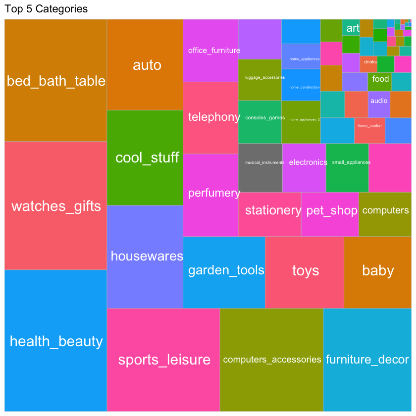

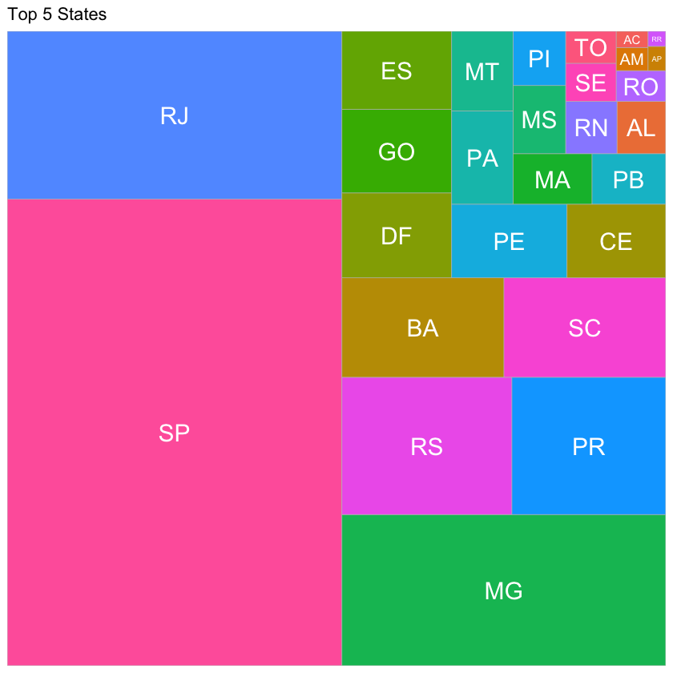

```r
# Top 5 graphics creation

categories_treemap_plot <- ggplot(top_element_per_revenue$categories, aes(area = revenue, fill = product_category_name)) +
    geom_treemap() +
    geom_treemap_text(aes(label = product_category_name), colour = "white", place = "centre") +
    labs(title = "Top 5 Categories") +
    theme(legend.position = "none")

states_treemap_plot <- ggplot(top_element_per_revenue$states, aes(area = revenue, fill = customer_state)) +
    geom_treemap() +
    geom_treemap_text(aes(label = customer_state), colour = "white", place = "centre") +
    labs(title = "Top 5 States") +
    theme(legend.position = "none")

categories_treemap_plot
states_treemap_plot
```

```r
# Show top 10 products, customers and sellers
head(top_element_per_revenue$products, 10)
head(top_element_per_revenue$customers, 10)
head(top_element_per_revenue$sellers, 10)
```

A tibble: 10 × 3

| product_id <chr> | product_category_name <chr> | revenue <dbl> |
| --- | --- | --- |
| bb50f2e236e5eea0100680137654686c | health_beauty | 67606.10 |
| d1c427060a0f73f6b889a5c7c61f2ac4 | computers_accessories | 60976.03 |
| 6cdd53843498f92890544667809f1595 | health_beauty | 59093.99 |
| 99a4788cb24856965c36a24e339b6058 | bed_bath_table | 51071.60 |
| d6160fb7873f184099d9bc95e30376af | computers | 50326.18 |
| 3dd2a17168ec895c781a9191c1e95ad7 | computers_accessories | 48212.22 |
| aca2eb7d00ea1a7b8ebd4e68314663af | furniture_decor | 44820.76 |
| 5f504b3a1c75b73d6151be81eb05bdc9 | cool_stuff | 41725.81 |
| 25c38557cf793876c5abdd5931f922db | baby | 40311.95 |
| 53b36df67ebb7c41585e8d54d6772e08 | watches_gifts | 39957.93 |

A tibble: 10 × 4

| customer_id <chr> | customer_city <chr> | customer_state <chr> | revenue <dbl> |
| --- | --- | --- | --- |
| 1617b1357756262bfa56ab541c47bc16 | rio de janeiro | RJ | 13664.08 |
| ec5b2ba62e574342386871631fafd3fc | vila velha | ES | 7274.88 |
| c6e2731c5b391845f6800c97401a43a9 | campo grande | MS | 6929.31 |
| f48d464a0baaea338cb25f816991ab1f | vitoria | ES | 6922.21 |
| 3fd6777bbce08a352fddd04e4a7cc8f6 | marilia | SP | 6726.66 |
| 05455dfa7cd02f13d132aa7a6a9729c6 | divinopolis | MG | 6081.54 |
| df55c14d1476a9a3467f131269c2477f | araruama | RJ | 4950.34 |
| e0a2412720e9ea4f26c1ac985f6a7358 | goiania | GO | 4809.44 |
| 24bbf5fd2f2e1b359ee7de94defc4a15 | maua | SP | 4764.34 |
| 3d979689f636322c62418b6346b1c6d2 | joao pessoa | PB | 4681.78 |

A tibble: 10 × 4

| seller_id <chr> | seller_city <chr> | seller_state <chr> | revenue <dbl> |
| --- | --- | --- | --- |
| 4869f7a5dfa277a7dca6462dcf3b52b2 | guariba | SP | 249640.7 |
| 7c67e1448b00f6e969d365cea6b010ab | itaquaquecetuba | SP | 239536.4 |
| 53243585a1d6dc2643021fd1853d8905 | lauro de freitas | BA | 235856.7 |
| 4a3ca9315b744ce9f8e9374361493884 | ibitinga | SP | 235540.0 |
| fa1c13f2614d7b5c4749cbc52fecda94 | sumare | SP | 204084.7 |
| da8622b14eb17ae2831f4ac5b9dab84a | piracicaba | SP | 185192.3 |
| 7e93a43ef30c4f03f38b393420bc753a | barueri | SP | 182754.1 |
| 1025f0e2d44d7041d6cf58b6550e0bfa | sao paulo | SP | 172860.7 |
| 7a67c85e85bb2ce8582c35f2203ad736 | sao paulo | SP | 162648.4 |
| 955fee9216a65b617aa5c0531780ce60 | sao paulo | SP | 160602.7 |

### Phase 2: Market Structure Analysis

Then we analyze the ABC of the products for inventory optimization.

```r
## Prepare monthly sales data summarization

monthly_sales <- merged_table %>%
    mutate(order_month = floor_date(as.Date(order_purchase_timestamp),"month")) %>%
    group_by(order_month) %>%
    summarise(
        total_revenue = sum(price, na.rm = TRUE),
        total_freight_value = sum(freight_value, na.rm = TRUE),
        total_orders = n_distinct(order_id),
        .groups = 'drop'
    ) %>%
arrange(order_month)

monthly_sales <- monthly_sales %>%
    pivot_longer(cols = c(total_revenue, total_freight_value), names_to = "metric", values_to = "value") %>%
    mutate(metric = case_when(
        metric == "total_revenue" ~ "Revenue",
        metric == "total_freight_value" ~ "Freight Value",
        TRUE ~ metric
    ))
```

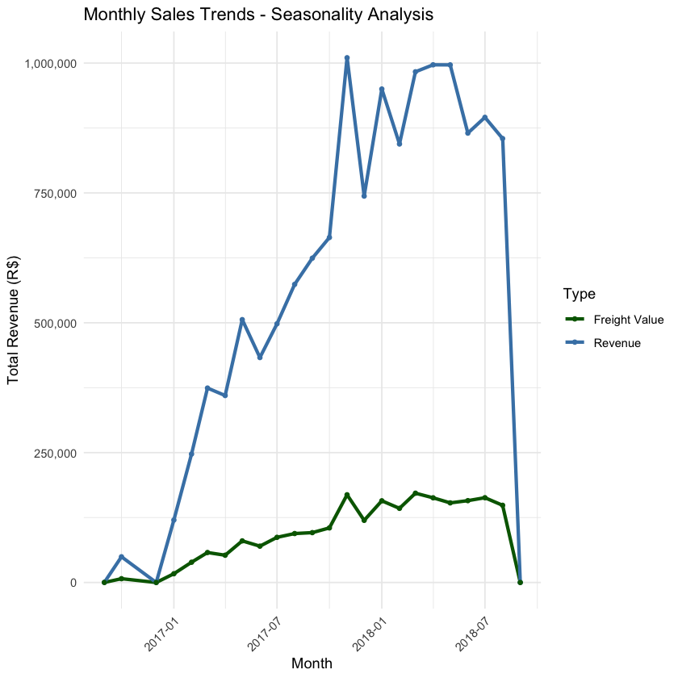

```r
# Line chart for monthly trends
monthly_trends_plot <- ggplot(monthly_sales, aes(x = order_month, y=value, color=metric)) +
    geom_line(linewidth = 1.2) +
    geom_point(size = 1.2) +
    scale_color_manual(values = c("Revenue" = "steelblue", "Freight Value" = "darkgreen")) +
    labs(
        title = "Monthly Sales Trends - Seasonality Analysis",
        x = "Month",
        y = "Total Revenue (R$)",
        color = "Type"
    ) +
    theme_minimal() +
    scale_y_continuous(labels = scales::comma) +
    theme(axis.text.x = element_text(angle = 45, hjust = 1))
monthly_trends_plot
```

As we can see, there's not apparent seasonality in the sales.

```r
# ABC Analysis of product categories

abc_analysis <- merged_table %>%
  group_by(product_category_name) %>%
  summarise(revenue = sum(price + freight_value, na.rm = TRUE), .groups = 'drop') %>%
  arrange(desc(revenue)) %>%
  mutate(
    cumulative_revenue = cumsum(revenue),
    total_revenue = sum(revenue),
    cumulative_percentage = cumulative_revenue / total_revenue * 100,
    rank = row_number()
  ) %>%
  mutate(
    abc_class = case_when(
    cumulative_percentage <= 80 ~ "A",
    cumulative_percentage <= 95 ~ "B",
    TRUE ~ "C"
    )
  )
```

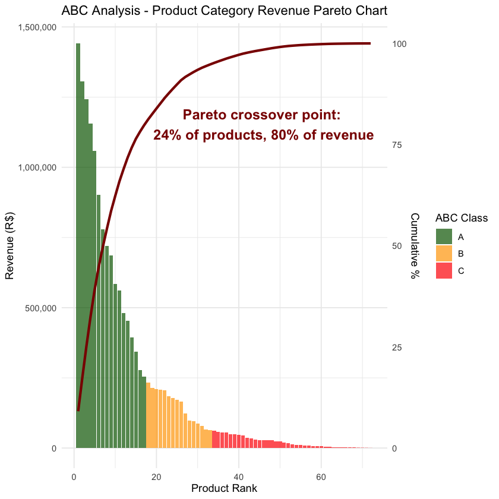

```r
# Pareto chart
pareto_plot <- ggplot(abc_analysis, aes(x = rank)) +
  geom_col(aes(y = revenue, fill = abc_class), alpha = 0.7) +
  geom_line(aes(y = cumulative_percentage * max(revenue) / 100), color = "darkred", size = 1.2) +
  scale_y_continuous(
    name = "Revenue (R$)",
    labels = scales::comma,
    sec.axis = sec_axis(~ . * 100 / max(abc_analysis$revenue), name = "Cumulative %")
  ) +
  scale_fill_manual(values = c("A" = "darkgreen", "B" = "orange", "C" = "red")) +
  labs(
    title = "ABC Analysis - Product Category Revenue Pareto Chart",
    x = "Product Rank",
    fill = "ABC Class"
  ) +
  theme_minimal()

# Pareto crossover point
pareto_crossover <- abc_analysis %>%
  filter(abc_class == "A") %>%
  tail(1)

pareto_crossover_x <- as.numeric(round(pareto_crossover[ , "rank"] / nrow(abc_analysis) * 100, 0))
pareto_crossover_y <- as.numeric(round(pareto_crossover[ , "cumulative_percentage"], 0))

annotation_x <- (pareto_crossover_x + 40) * max(abc_analysis$rank) / 100
annotation_y <- pareto_crossover_y * max(abc_analysis$revenue) / 100

pareto_plot <- pareto_plot +
    annotate("text", x = annotation_x, y = annotation_y, label = paste("\nPareto crossover point: ", "\n", pareto_crossover_x, "% of products, ", pareto_crossover_y, "% of revenue\n", sep = ""), color = "darkred", size = 5, fontface = "bold")

pareto_plot
```

In categories, there is a standard Pareto classification. Nothing particulare to signal.

```r
location_metrics <- merged_table %>%
  group_by(customer_state) %>%
  summarise(
    total_revenue = sum(price + freight_value, na.rm = TRUE),
    total_quantity = n(),
    avg_order_value = total_revenue / n_distinct(order_id),
    .groups = 'drop'
  )
```

```r
# Geographical heatmap

# Get the map data
brazil_map <- map_data("world") %>%
  filter(region == "Brazil")

# Merge the map data with the location metrics
zip_revenue_heatmap <- merged_table %>%
  group_by(customer_zip_code_prefix, customer_lat, customer_lng) %>%
  summarise(
    revenue = sum(price + freight_value, na.rm = TRUE),
    orders = n_distinct(order_id),
    customers = n_distinct(customer_id),
    .groups = 'drop'
  ) %>%
  filter(!is.na(customer_lat), !is.na(customer_lng), revenue > 0)

# Remove outliers
revenue_threshold <- quantile(zip_revenue_heatmap$revenue, 0.99)
zip_filtered <- zip_revenue_heatmap %>%
  filter(revenue <= revenue_threshold)
```

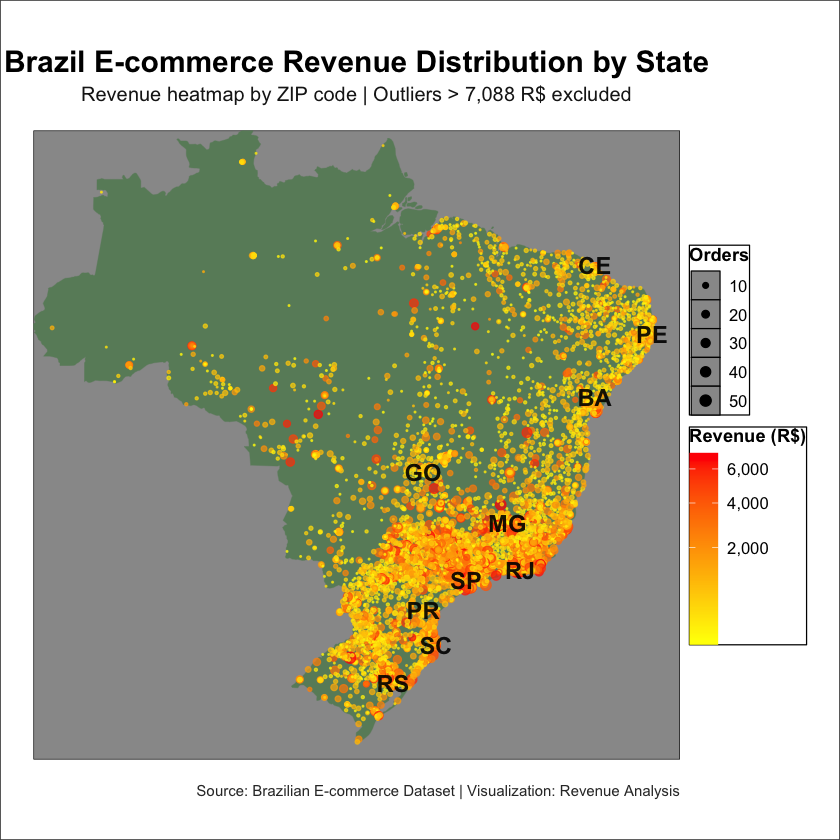

```r
brazil_states_heatmap <- ggplot() +
  geom_polygon(
    data = brazil_map,
    aes(x = long, y = lat, group = group),
    fill = "darkseagreen4", color = "darkseagreen4", size = 0.1
  ) +
  geom_point(
    data = zip_filtered,
    aes(x = customer_lng, y = customer_lat, color = revenue, size = orders), alpha = 0.7
  ) +
  scale_color_gradient(
    low = "#ffff00",
    high = "#ff0000",
    name = "Revenue (R$)",
    labels = scales::comma_format(),
    trans = "sqrt",
    guide = guide_colorbar(
      barwidth = 1.2,
      barheight = 8,
      title.position = "top"
    )
  ) +
  scale_size_continuous(
    range = c(0.2, 3),
    name = "Orders",
    labels = scales::comma_format(),
    guide = guide_legend(
      override.aes = list(alpha = 1),
      title.position = "top",
      title.hjust = 0.5
    )
  ) +
  coord_fixed(xlim = c(-72, -35), ylim = c(-33, 3)) +
  labs(
    title = "Brazil E-commerce Revenue Distribution by State",
    subtitle = paste("Revenue heatmap by ZIP code | Outliers >", scales::comma(revenue_threshold), "R$ excluded"),
    caption = "Source: Brazilian E-commerce Dataset | Visualization: Revenue Analysis",
    x = "Longitude",
    y = "Latitude"
  ) +
  theme_void() +
  theme(
    plot.title = element_text(hjust = 0.5, color = "black", size = 18, face = "bold", margin = margin(10,0,5,0)),
    plot.subtitle = element_text(hjust = 0.5, color = "grey10", size = 12, margin = margin(0,0,15,0)),
    plot.caption = element_text(hjust = 1, color = "grey20", size = 9, margin = margin(15,0,5,0)),
    panel.background = element_rect(fill = "gray60"),
    plot.background = element_rect(fill = "white"),
    legend.position = "right",
    legend.text = element_text(color = "black", size = 10),
    legend.title = element_text(color = "black", size = 11, face = "bold"),
    legend.background = element_rect(fill = "white"),
    plot.margin = margin(20, 20, 20, 20)
  )

main_states <- data.frame(
  state = c("SP", "RJ", "MG", "RS", "PR", "SC", "GO", "BA", "PE", "CE"),
  lng = c(-46.6, -43.2, -44.0, -51.2, -49.3, -48.5, -49.3, -38.5, -34.9, -38.5),
  lat = c(-23.5, -22.9, -19.9, -30.0, -25.4, -27.6, -16.7, -12.0, -8.0, -3.7)
)

brazil_labeled_heatmap <- brazil_states_heatmap +
  geom_text(data = main_states,
            aes(x = lng, y = lat, label = state),
            color = "black", size = 5, fontface = "bold",
            alpha = 0.9)

brazil_labeled_heatmap
```

Looking the map we can see the geographical concentration of the sales, that's crucial on a logistic point of view.